# Part I - (Dataset Exploration Title)

## Data Cleaning

- ### Define

Drop id column since it is a clutter

- ### Code

```python
df =  df.drop("id", axis=1)
```

- ### Test

```python
df.columns
```

```
Index(['diagnosis', 'radius_mean', 'texture_mean', 'perimeter_mean',
       'area_mean', 'smoothness_mean', 'compactness_mean', 'concavity_mean',
       'concave_points_mean', 'symmetry_mean', 'fractal_dimension_mean',
       'radius_se', 'texture_se', 'perimeter_se', 'area_se', 'smoothness_se',
       'compactness_se', 'concavity_se', 'concave_points_se', 'symmetry_se',
       'fractal_dimension_se', 'radius_worst', 'texture_worst',
       'perimeter_worst', 'area_worst', 'smoothness_worst',
       'compactness_worst', 'concavity_worst', 'concave_points_worst',
       'symmetry_worst', 'fractal_dimension_worst'],
      dtype='object')
```

- ### Define

Drop null values

- ### Code

```python
df.dropna(inplace = True)
```

- ### Test

```python
df.isnull().sum()
```

```
diagnosis                  0
radius_mean                0
texture_mean               0
perimeter_mean             0
area_mean                  0
smoothness_mean            0
compactness_mean           0
concavity_mean             0
concave_points_mean        0
symmetry_mean              0
fractal_dimension_mean     0
radius_se                  0
texture_se                 0
perimeter_se               0
area_se                    0
smoothness_se              0
compactness_se             0
concavity_se               0
concave_points_se          0
symmetry_se                0
fractal_dimension_se       0
radius_worst               0
texture_worst              0
perimeter_worst            0
area_worst                 0
smoothness_worst           0
compactness_worst          0
concavity_worst            0
concave_points_worst       0
symmetry_worst             0
fractal_dimension_worst    0
dtype: int64
```

- ### Define

Drop duplicate values

- ### Code

```python
df = df.drop_duplicates()
```

- ### Test

```python
df.duplicated().sum()
```

```
0
```

```python
df.info()
```

```
<class 'pandas.core.frame.DataFrame'>
Int64Index: 604 entries, 0 to 618
Data columns (total 31 columns):
diagnosis                  604 non-null object
radius_mean                604 non-null float64
texture_mean               604 non-null float64
perimeter_mean             604 non-null float64
area_mean                  604 non-null float64
smoothness_mean            604 non-null float64
compactness_mean           604 non-null float64
concavity_mean             604 non-null float64
concave_points_mean        604 non-null float64
symmetry_mean              604 non-null float64
fractal_dimension_mean     604 non-null float64
radius_se                  604 non-null float64
texture_se                 604 non-null float64
perimeter_se               604 non-null float64
area_se                    604 non-null float64
smoothness_se              604 non-null float64
compactness_se             604 non-null float64
concavity_se               604 non-null float64
concave_points_se          604 non-null float64
symmetry_se                604 non-null float64
fractal_dimension_se       604 non-null float64
radius_worst               604 non-null float64
texture_worst              604 non-null float64
perimeter_worst            604 non-null float64
area_worst                 604 non-null float64
smoothness_worst           604 non-null float64
compactness_worst          604 non-null float64
concavity_worst            604 non-null float64
concave_points_worst       604 non-null float64
symmetry_worst             604 non-null float64
fractal_dimension_worst    604 non-null float64
dtypes: float64(30), object(1)
memory usage: 151.0+ KB
```

```python
df.describe()
```

|  | radius_mean | texture_mean | perimeter_mean | area_mean | smoothness_mean | compactness_mean | concavity_mean | concave_points_mean | symmetry_mean | fractal_dimension_mean | ... | radius_worst | texture_worst | perimeter_worst | area_worst | smoothness_worst | compactness_worst | concavity_worst | concave_points_worst | symmetry_worst | fractal_dimension_worst |
| --- | --- | --- | --- | --- | --- | --- | --- | --- | --- | --- | --- | --- | --- | --- | --- | --- | --- | --- | --- | --- | --- |
| count | 604.000000 | 604.000000 | 604.000000 | 604.000000 | 604.000000 | 604.000000 | 604.000000 | 604.000000 | 604.000000 | 604.000000 | ... | 604.000000 | 604.000000 | 604.000000 | 604.000000 | 604.000000 | 604.000000 | 604.000000 | 604.000000 | 604.000000 | 604.000000 |
| mean | 14.240390 | 19.011325 | 88.070050 | 638.394454 | 0.095996 | 0.103972 | 0.092236 | 0.051393 | 0.184238 | 0.070274 | ... | 15.737711 | 26.489688 | 102.666828 | 851.875629 | 0.144155 | 0.251325 | 0.272009 | 0.117838 | 0.279312 | 0.091768 |
| std | 3.766162 | 4.401026 | 28.689362 | 358.717201 | 0.015324 | 0.051917 | 0.086168 | 0.042089 | 0.104001 | 0.037265 | ... | 5.493254 | 10.367344 | 37.669472 | 579.436064 | 0.088513 | 0.158841 | 0.209310 | 0.075115 | 0.077108 | 0.046639 |
| min | -0.007594 | 7.690000 | 11.280000 | 70.870000 | 0.023400 | 0.019380 | 0.000000 | 0.000000 | 0.006588 | 0.049960 | ... | 0.001020 | 11.990000 | 14.200000 | 76.250000 | 0.000000 | 0.027290 | 0.000000 | 0.000000 | 0.001444 | 0.055040 |
| 25% | 11.707500 | 15.827500 | 73.492500 | 408.650000 | 0.085948 | 0.065945 | 0.030270 | 0.020698 | 0.159550 | 0.058225 | ... | 12.767500 | 20.820000 | 81.797500 | 491.300000 | 0.116500 | 0.140100 | 0.113925 | 0.065470 | 0.244200 | 0.072048 |
| 50% | 13.435000 | 18.635000 | 84.915000 | 540.250000 | 0.095865 | 0.094145 | 0.066575 | 0.035450 | 0.177900 | 0.061985 | ... | 14.785000 | 25.245000 | 95.915000 | 662.500000 | 0.131600 | 0.208150 | 0.225250 | 0.099425 | 0.278050 | 0.080640 |
| 75% | 16.132500 | 21.592500 | 102.725000 | 768.325000 | 0.105400 | 0.129725 | 0.133825 | 0.077363 | 0.195400 | 0.067277 | ... | 18.255000 | 30.060000 | 123.425000 | 1031.250000 | 0.147575 | 0.327125 | 0.379925 | 0.162575 | 0.315550 | 0.093545 |
| max | 28.110000 | 39.280000 | 188.500000 | 2501.000000 | 0.163400 | 0.345400 | 0.920000 | 0.227300 | 1.931000 | 0.560000 | ... | 36.040000 | 101.900000 | 251.200000 | 4254.000000 | 0.874000 | 1.058000 | 1.252000 | 0.694300 | 0.663800 | 0.437800 |

8 rows × 30 columns

### What is/are the main feature(s) of interest in your dataset?

> I'm most interested in figuring out which which mean measurement of radius, perimeter,area and other similar measurement and how they affect the possibility of that cell being non-cancerous,or benign(B), and how these sizes affects a cell being cancerous or more appropraitely, malignant(M). There is also a pre-malignant(P)

### What features in the dataset do you think will help support your investigation into your feature(s) of interest?

> The diagnosis,perimeter_mean, radius_mean, area_mean

## Univariate Exploration

### What are the distribution of the various variables like?

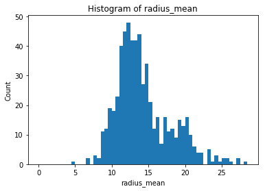

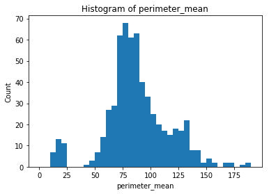

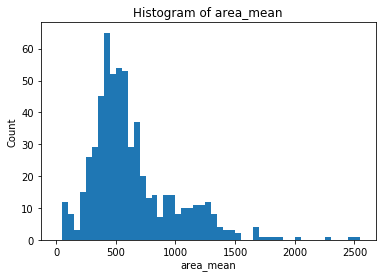

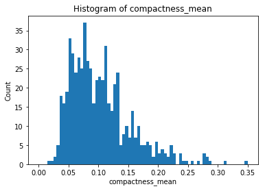

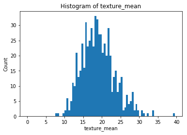

```python
varnames = ['radius_mean', 'perimeter_mean', 'area_mean', 'compactness_mean','texture_mean']
binsizes = [0.5, 5, 50,0.005, 0.5]
def plot_histograms(df, varnames, binsizes):
    # Loop through each variable
    for i, varname in enumerate(varnames):
        # Calculate bins using the corresponding binsize
        bins = np.arange(0, df[varname].max()+binsizes[i], binsizes[i])

        # Create histogram using Matplotlib's hist function
        plt.hist(df[varname], bins=bins)

        # Add labels and title
        plt.xlabel(varname)
        plt.ylabel("Count")
        plt.title(f"Histogram of {varname}")

        # Show the plot
        plt.show()

plot_histograms(df, varnames, binsizes)
```

> This distribution of the radius_mean looks has a look of a normal distribution, but drags on to be the right to make it right skewed. It could be seen that majority of the values fall between 10 to 20, with a slight drop in between.

> This is rather interesting, having quite a number of values start between 15 to 25 before having right skewed look,starting from 50 ending at the 175 value. Could the earlier values be incorrect value recording or just unique values?

> Area mean is glaringly right skewed with a bit of drag,which does ends in one view, thus not necesitating a log plot. It however have disparate distrubtion going from the 1500 value updwards.

> Just like the usual right skew trend, the compactness measurement looks to follow the others. The peak values from this looks to be from the 0.05 to 0.12

> Out of all the considered variables, this is the closest thing to normal distribution. This could probably be because texture had values have range of values which are predifined values which the instrument of measurement chooses.

### What is the genral distribution of all numerical variables?

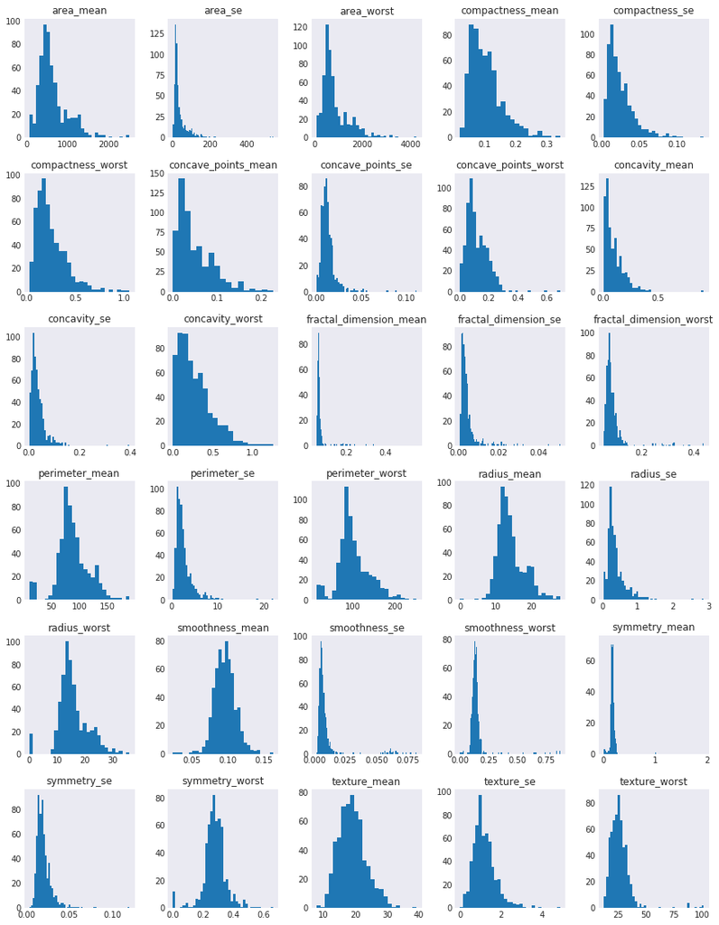

```python
#distribution plot

sb.set_style("darkgrid")
df.hist(figsize=(15, 20), grid=False, bins="auto");
```

### What are the count of the categorical variable?

```
Malignant Patient Count: 212
Pre-Malignant Patient Count: 34
Benign Patient Count: 358
```

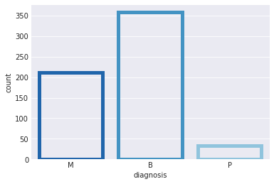

```python
sb.countplot(
    x="diagnosis",
    facecolor=(0, 0, 0, 0),
    linewidth=5,
    edgecolor=sb.color_palette("RdBu_r", 9),
    data=df,
)
print(
    "Malignant Patient Count: {}".format(df[df["diagnosis"] == "M"]["diagnosis"].count())
)
print(
    "Pre-Malignant Patient Count: {}".format(df[df["diagnosis"] == "P"]["diagnosis"].count())
)
print(
    "Benign Patient Count: {}".format(df[df["diagnosis"] == "B"]["diagnosis"].count())
);
```

As seen, the categorical variable contains three distinct values, benign(B), pre-malignant(P) and malignant cells. The benign cells dominate with 358 counts,followed by malignant cells with count of 212 and lastly pre-malignant cells with only 34 values

## Bivariate Exploration

Are there any correlation between some of the variables?

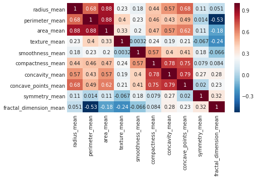

```python
corr_mean = df[['radius_mean','perimeter_mean','area_mean','texture_mean','smoothness_mean','compactness_mean',
                'concavity_mean','concave_points_mean','symmetry_mean','fractal_dimension_mean']]
plt.figure(figsize=(7,4))
sb.heatmap(corr_mean.corr(),annot=True,cmap='RdBu_r');
```

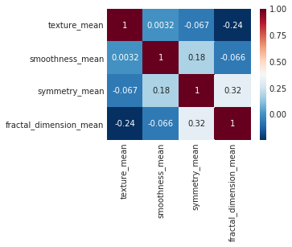

```python
#looking into the correlation between texture,smoothness,symmetry and fractal means
tssf_mean = df[["texture_mean", "smoothness_mean","symmetry_mean","fractal_dimension_mean"]]
plt.figure(figsize=(4,3))
sb.heatmap(tssf_mean.corr(),annot=True,cmap='RdBu_r');
```

> The radius, perimeter, area, concavity, and concavity of the dataset have a significant degree of correlation with one another suggesting dependency of eachother.

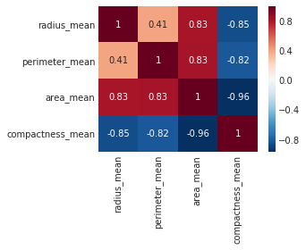

```python
drpac_mean = df[["diagnosis", "radius_mean", "perimeter_mean", "area_mean","compactness_mean"]].corr()
plt.figure(figsize=(4,3))
sb.heatmap(drpac_mean.corr(),annot=True,cmap='RdBu_r');
```

### But are these values truly follow a perculiar trend? I use a pairplot to answer that question below

# Pairplot of Features

## Characterisation by field groupings

Involves grouping the attributes in order to find similarities between fields of the same class;

```python
mean_selections = df[["diagnosis", "radius_mean", "perimeter_mean", "area_mean", "compactness_mean"]]
```

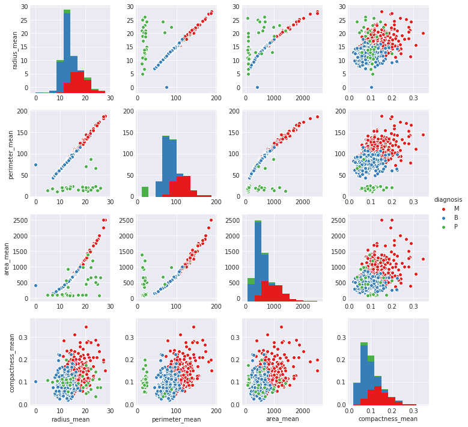

```python
sb.pairplot(mean_selections, hue="diagnosis", palette="Set1");
```

Observing the pairplots, there's a common trend amongst the benign and malignant cells. The benign cells have lower values whiles the malignant cells have larger values. So benign cells have lower radius, lower perimeter,lower area and lower compactness values. Even though there are outliers, these are few and does not invalidate the general trend. THe pre-malignant cells however, have no direct trend and suggest it is difficult to predict from it whether a cell is benign or malignant

### How are the distribution of count like percentage wise? I use a donut plot to look into that below

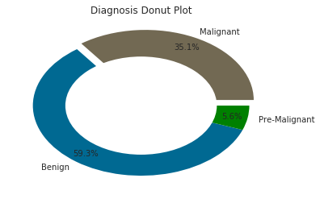

```python
#setting size in chart based on
Diagnosis = [
    df[df["diagnosis"] == "M"]["diagnosis"].count(),
    df[df["diagnosis"] == "B"]["diagnosis"].count(),
    df[df["diagnosis"] == "P"]["diagnosis"].count(),
]
label = ["Malignant", "Benign","Pre-Malignant"]
#colors
colors = ["#726953", "#006992","#008000"]

#explosion
explode = (0.09, 0.00,0.00)

#pie chart
plt.pie(
    Diagnosis,
    colors=colors,
    labels=label,
    autopct="%1.1f%%",
    pctdistance=0.85,
    explode=explode,
)

#insert circle in chart
centre_circle = plt.Circle((0, 0), 0.70, fc="white")
fig = plt.gcf()
fig.gca().add_artist(centre_circle)

#add title of chart
plt.title("Diagnosis Donut Plot");
```

> The diagnosis donut chart shows the percentage of distribution of the three various cell types with benign(B) dominating at 59.3 percent, followed by malignant(M) cells which has 35.1% and lastly pre-malignant(P) cells have just as few as 5.6%

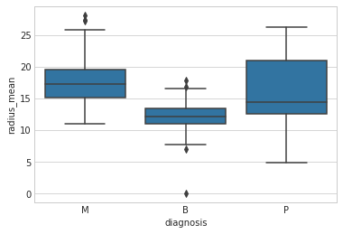

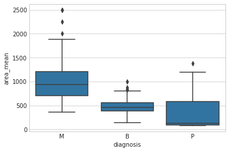

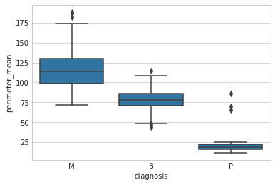

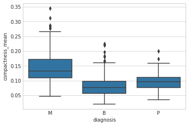

```python
def plot_boxplot(data):
    # set plot style
    sb.set_style("whitegrid")
    color = sb.color_palette()[0]
    # create boxplot for each numerical column
    for col in ["radius_mean", "area_mean", "perimeter_mean", "compactness_mean"]:
        sb.boxplot(x="diagnosis", y=col, data=data,color = color)
        # show plot
        plt.show()
plot_boxplot(df)
```

It is more obvious from the plots above that that malignant cells have higher average radius, area,compactness and perimeter sizes than both benign and premalignant cells. This suggest negative relationship amongst them

## Multivariate Exploration

How distant are the lower and upper boundary values amongst the diagnosis values?

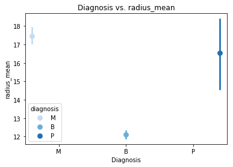

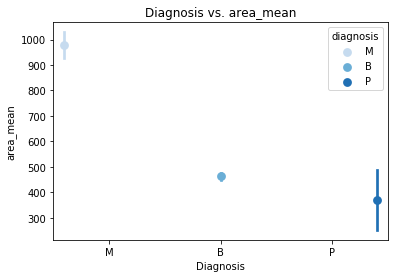

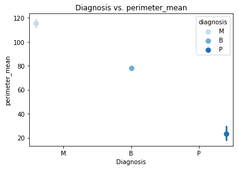

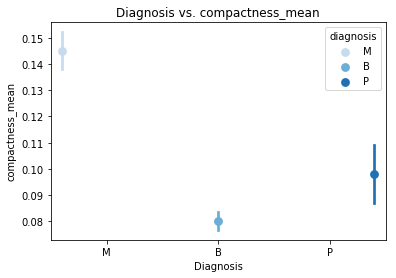

```python
def plot_diagnosis_vs_feature(df, feature):
    # Create a pointplot using Seaborn
    sb.pointplot(x='diagnosis', y=feature, data=df, hue = 'diagnosis',
           palette = 'Blues', linestyles = '', dodge = 0.8)

    # Add labels and title
    plt.xlabel('Diagnosis')
    plt.ylabel(feature)
    plt.title('Diagnosis vs. {}'.format(feature))

    # Show the plot
    plt.show()
plot_diagnosis_vs_feature(df, 'radius_mean')
plot_diagnosis_vs_feature(df, 'area_mean')
plot_diagnosis_vs_feature(df, 'perimeter_mean')
plot_diagnosis_vs_feature(df, 'compactness_mean')
```

> Yes, malignant cells have higher values followed by pre-malignant values, with benign cells having the least radius. However, pre-malignant cells are seen to have the widest range of radius span than the other two,which shows it contains more random measurement than the other two.

> It follows again, that malignant cells have the largest value of areas. This time round though, benign cells follow up and pre-malignant cells have the least values. Yet it is confirmed again that it contains more random and wide measurement of values

> The trend follows similarly for perimeter and compactness. This confirms that, pre-malignant cells are randomly distributed, but benign cells are smaller in sizes based radius,area,perimeter and compactness whiles malignant cells are larger in sizes on these same criterias

### Interesting findings

> A general relationship observed, which was surprising was that, I expected the pre-malignant cells to have had features in between benign and malignant. However,it turned out it was not direct an did not have a definite relationship. This means more care and experience is needed to declare it as pre-malignant.

## Conclusions

> It was observed that generally, benign cells had smaller radius, smaller perimeter, smaller area and compactness than malignant cells. Larger cell measurement values suggest strong likelihood of malignant cells and less values of measurement suggest benign cells.

> More than half of the cells were benign, yet an significant number of the cells, i.e 35.1% of the cells are malignant.

> The measurement values of radius, perimeter, area, concavity, and concavity of the dataset have a significant degree of correlation with one another suggesting multicollinearity.